# Practicum 1 DA 5020

Jiaming Xu

```r
library(tidyverse)
library(XML)
library(httr)
library(rvest)
```

## Step 1: Importing data.

Retrieving XML information from url, navigate to first children node and convert to data frame. Then, change variable types automatically using type_convert function.

```r
url = "https://data.ny.gov/api/views/ngbt-9rwf/rows.xml"
xml_raw = xmlRoot(xmlParse(GET(url)))
df_ori <- xmlToDataFrame(xml_raw[[1]]) %>% as_tibble()
df <- readr::type_convert(df_ori)
```

## Step 2:

### County, program_category, and primary_substance_group tibbles.

### 1. Checking if there’s any missing data in data set. No missing values.

```r
sapply(df,function(x) sum(is.na(x)))
```

```
##                       year county_of_program_location
##                          0                          0
##           program_category               service_type
##                          0                          0
##                  age_group    primary_substance_group
##                          0                          0
##                 admissions
##                          0
```

###2. Checking summary:

From summary function output we can see, only year and admissions columns are numeric, the rests are character. Year ranges from 2007 to 2020; admissions range from 1 to 2862, with 42.81 as mean. Therefore, there are many outliers in this data set.

```r
summary(df)
```

```
##       year      county_of_program_location program_category
##  Min.   :2007   Length:92907               Length:92907
##  1st Qu.:2010   Class :character           Class :character
##  Median :2014   Mode  :character           Mode  :character
##  Mean   :2014
##  3rd Qu.:2017
##  Max.   :2020
##  service_type        age_group         primary_substance_group
##  Length:92907       Length:92907       Length:92907
##  Class :character   Class :character   Class :character
##  Mode  :character   Mode  :character   Mode  :character
##
##
##
##    admissions
##  Min.   :   1.00
##  1st Qu.:   3.00
##  Median :   8.00
##  Mean   :  42.81
##  3rd Qu.:  29.00
##  Max.   :2862.00
```

One way to handle these outliers are analyzing them separately. Therefore save outliers to data set df_outliers. Criteria here is z > 3.

```r
df_outliers <- df %>%
  mutate( z = (admissions - mean(admissions)) / sd(admissions)) %>%
  filter( abs(z) > 3)

df_clean <- df %>%
  mutate( z = (admissions - mean(admissions)) / sd(admissions)) %>%
  filter( abs(z) <= 3) %>%
  select( -z)
```

### 3. According to str results, looking each categorical variables.

```r
str(df_clean)
```

```
## tibble [91,099 × 7] (S3: tbl_df/tbl/data.frame)
##  $ year                      : num [1:91099] 2007 2007 2007 2007 2007 ...
##  $ county_of_program_location: chr [1:91099] "Albany" "Albany" "Albany" "Albany" ...
##  $ program_category          : chr [1:91099] "Crisis" "Crisis" "Crisis" "Crisis" ...
##  $ service_type              : chr [1:91099] "Medical Managed Detoxification" "Medical Managed Detoxification" "Medical Managed Detoxification" "Medical Managed Detoxification" ...
##  $ age_group                 : chr [1:91099] "Under 18" "55 and Older" "55 and Older" "55 and Older" ...
##  $ primary_substance_group   : chr [1:91099] "Heroin" "Alcohol" "All Others" "Heroin" ...
##  $ admissions                : num [1:91099] 4 192 1 30 4 402 6 152 14 376 ...
```

```r
unique(df_clean$county_of_program_location)
```

```
##  [1] "Albany"         "Allegany"       "Bronx"          "Broome"
##  [5] "Cattaraugus"    "Cayuga"         "Chautauqua"     "Chemung"
##  [9] "Chenango"       "Clinton"        "Columbia"       "Cortland"
## [13] "Delaware"       "Dutchess"       "Erie"           "Essex"
## [17] "Franklin"       "Fulton"         "Genesee"        "Greene"
## [21] "Herkimer"       "Jefferson"      "Kings"          "Lewis"
## [25] "Livingston"     "Madison"        "Monroe"         "Montgomery"
## [29] "Nassau"         "New York"       "Niagara"        "Oneida"
## [33] "Onondaga"       "Ontario"        "Orange"         "Orleans"
## [37] "Oswego"         "Otsego"         "Putnam"         "Queens"
## [41] "Rensselaer"     "Richmond"       "Rockland"       "Saint Lawrence"
## [45] "Saratoga"       "Schenectady"    "Schoharie"      "Schuyler"
## [49] "Seneca"         "Steuben"        "Suffolk"        "Sullivan"
## [53] "Tioga"          "Tompkins"       "Ulster"         "Warren"
## [57] "Washington"     "Wayne"          "Westchester"    "Wyoming"
## [61] "Yates"
```

```r
unique(df_clean$program_category)
```

```
## [1] "Crisis"                   "Inpatient"
## [3] "Opioid Treatment Program" "Outpatient"
## [5] "Residential"              "Specialized"
```

```r
unique(df_clean$service_type)
```

```
##  [1] "Medical Managed Detoxification"    "Medically Monitored Withdrawal"
##  [3] "Inpatient Rehabilitation"          "Opioid Outpatient Treatment"
##  [5] "Outpatient Clinic"                 "Outpatient Rehabilitation"
##  [7] "Community Residential"             "Intensive Residential"
##  [9] "Residential Rehab for Youth"       "Supportive Living"
## [11] "Specialized Outpatient - TBI"      "Med Sup Withdrawal - Inpatient"
## [13] "Limited Outpatient/KEEP"           "MAOT-A-Residential"
## [15] "Outpat Chem Depend for Youth"      "Short Term Res CD/Youth"
## [17] "Long Term Res CD/Youth"            "Med Sup Withdrawal-Outpatient"
## [19] "Non-Med Sup Chem Depend OP"        "OTP Intensive Residential"
## [21] "Specialized Services Outpt Rehab"  "Specialized Outpatient - Mobile"
## [23] "Stabilization Rehab Reintegration" "Residential Stabilization"
## [25] "Rehab and Reintegration"           "Residential Reintegration"
## [27] "Stabilization and Rehab"           "Residential Rehabilitation"
```

```r
unique(df_clean$age_group)
```

```
## [1] "Under 18"     "55 and Older" "45 thru 54"   "35 thru 44"   "25 thru 34"
## [6] "18 thru 24"
```

```r
unique(df_clean$primary_substance_group)
```

```
## [1] "Heroin"                 "Alcohol"                "All Others"
## [4] "Other Opioids"          "Cocaine incl Crack"     "Marijuana incl Hashish"
## [7] "None"
```

Only primary_substance_group contains unusual data “None”. Delete corresponding rows.

```r
# Row 5840 contains No primary_substance_group information, therefore delete it.
df_clean <- df_clean[-which(df_clean$primary_substance_group == "None"), ]
```

### 4. Potential aditional analysis.

Since different county has different population, it’s a good idea to also calculate addiction percentage over population. Import data from New York State goverment website.

```r
ny_pop <- read_csv("https://data.ny.gov/resource/krt9-ym2k.csv")
```

### 5. Annual Admissions over time:

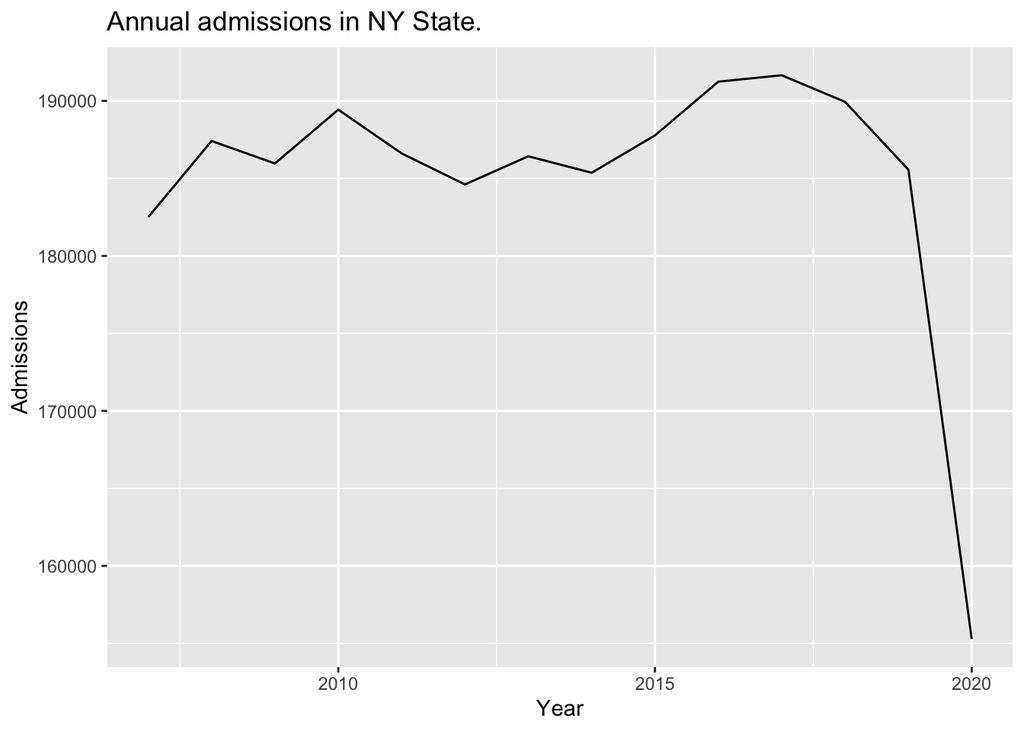

```r
df_clean %>%
  group_by( year) %>%
  summarise( annual_adm = sum(admissions)) %>%
  ggplot() +
  geom_line( mapping = aes( x = year, y = annual_adm)) +
  labs( x = "Year", y ="Admissions", title = "Annual admissions in NY State.")
```

## Part 3:

### 1. Create county_dict.

Contains two variables - county_code and county_name. Data took from website provided in the practicum 1 pdf.

county_code: Two or Three letters for county name abbreviation.

county_name: county names in New York State.

Error occurs when imported data from url directly, therefore I download html file to disk then import. Also there are mismathes between dataset and county list, unify them by changing county_dict.

```r
county_raw <- read_html("CountryCodeLists.html")
county <- county_raw %>%
  html_element("tbody") %>%
  html_table()

county_dict <- cbind(as_tibble(unlist(cbind(county[ , c(2,4,6,8)]))),
      as_tibble(unlist(cbind(county[ , c(1,3,5,7)])))) %>%
  `colnames<-`(c("county_code", "county_name"))

county_dict[24,1] <- "NA"
county_dict <- county_dict[-48,] %>% drop_na()
county_dict$county_name <- str_to_title(county_dict$county_name)

# Make sure 5 Boroughs of New York have unique county code.
county_dict[11,1] <- "NYQ"
county_dict[33,1] <- "NYB"
county_dict[40,1] <- "NYC"
county_dict[43,1] <- "NYR"
county_dict[53,1] <- "NYK"

county_dict
```

| county_code | county_name |
| --- | --- |
| AL | Albany |
| CA | Cattaraugus |
| CN | Chenango |
| DE | Delaware |
| FR | Franklin |
| HA | Hamilton |
| LE | Lewis |
| MG | Montgomery |
| ON | Oneida |
| OL | Orleans |

[output cut: 52 more lines]

### 2. Create program_category_dict.

```r
# Create program_category dictionary.
program_category_dict <- cbind(1:6, unique(df_clean$program_category)) %>%
  as_tibble() %>%
  `colnames<-`(c("program_code", "program_category"))
program_category_dict
```

| program_code | program_category |
| --- | --- |
| 1 | Crisis |
| 2 | Inpatient |
| 3 | Opioid Treatment Program |
| 4 | Outpatient |
| 5 | Residential |
| 6 | Specialized |

### 3. Create primary_substance_dict.

```r
# Create primary_substance_group dictionary.
primary_substance_dict <- cbind(1:6, unique(df_clean$primary_substance_group)) %>%
  as_tibble() %>%
  `colnames<-`(c("substance_code", "primary_substance_group"))

primary_substance_dict
```

| substance_code | primary_substance_group |
| --- | --- |
| 1 | Heroin |
| 2 | Alcohol |
| 3 | All Others |
| 4 | Other Opioids |
| 5 | Cocaine incl Crack |
| 6 | Marijuana incl Hashish |

### 4. Processing admission_data.

1. Changing “Saint” by “St.” for Saint Lawrence, “New York” by “New York (City)” to match county_name in county_dict.
2. Replacing whole names by abbreviations.

```r
# Capitalize county names.
df_clean$county_of_program_location <- str_to_title(df_clean$county_of_program_location)
# Convert Santa to St. in df.
df_clean$county_of_program_location <- str_replace_all(df_clean$county_of_program_location,
                                                 c('Saint' = 'St.',
                                                   "New York" = "New York (City)"))

admissions_data <- df_clean %>%
  mutate( county_of_program_location = county_dict$county_code[match(county_of_program_location, county_dict$county_name)]) %>%
  mutate( program_category = program_category_dict$program_code[match(program_category, program_category_dict$program_category)]) %>%
  mutate( primary_substance_group = primary_substance_dict$substance_code[match(primary_substance_group, primary_substance_dict$primary_substance_group)])

admissions_data
```

| year | county_of_program_location | program_category | service_type | age_group | primary_substance_group | admissions |
| --- | --- | --- | --- | --- | --- | --- |
| 2007 | AL | 1 | Medical Managed Detoxification | Under 18 | 1 | 4 |
| 2007 | AL | 1 | Medical Managed Detoxification | 55 and Older | 2 | 192 |
| 2007 | AL | 1 | Medical Managed Detoxification | 55 and Older | 3 | 1 |
| 2007 | AL | 1 | Medical Managed Detoxification | 55 and Older | 1 | 30 |
| 2007 | AL | 1 | Medical Managed Detoxification | 55 and Older | 4 | 4 |
| 2007 | AL | 1 | Medical Managed Detoxification | 45 thru 54 | 2 | 402 |
| 2007 | AL | 1 | Medical Managed Detoxification | 45 thru 54 | 3 | 6 |
| 2007 | AL | 1 | Medical Managed Detoxification | 45 thru 54 | 1 | 152 |
| 2007 | AL | 1 | Medical Managed Detoxification | 45 thru 54 | 4 | 14 |
| 2007 | AL | 1 | Medical Managed Detoxification | 35 thru 44 | 2 | 376 |

[output cut: 9990 more lines]

## Part 4: annualAdmission function.

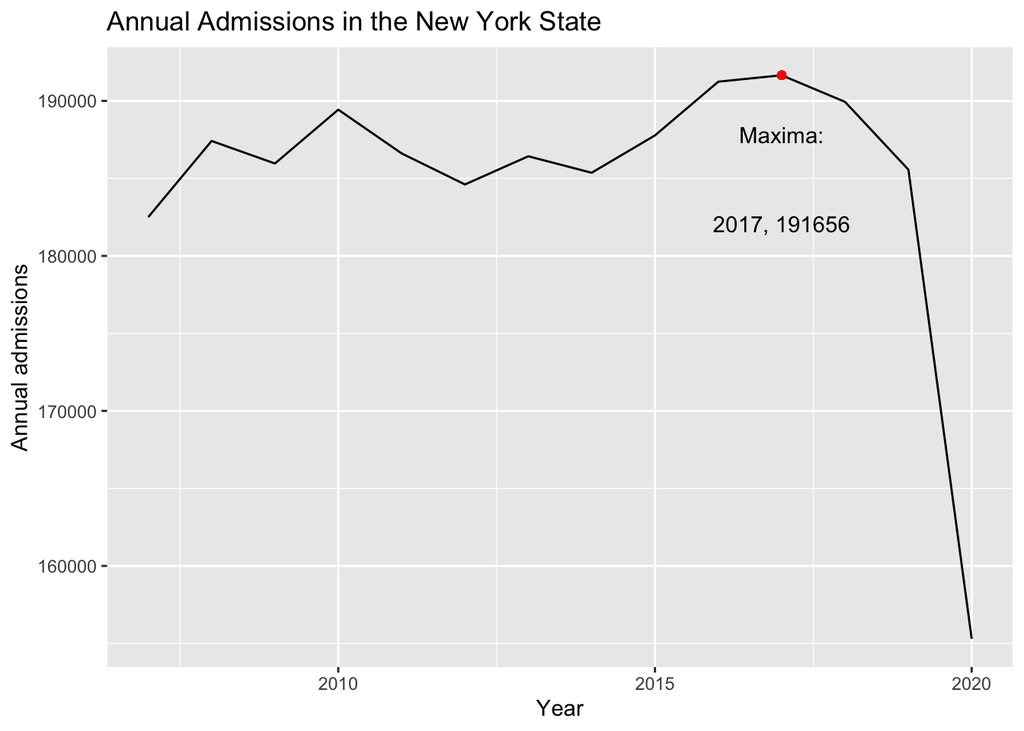

```r
annualAdmission <- function(){
df_gbyear <- admissions_data %>%
    group_by( year) %>%
    summarise( total_adm = sum(admissions))

max.year <- df_gbyear %>%
    filter(total_adm == max(total_adm))

df_gbyear %>%
    ggplot() +
    geom_line(mapping = aes( x = year, y = total_adm)) +
    geom_point(mapping = aes( x = max.year$year, y = max.year$total_adm), color = 'red')+
    annotate("text", label = "Maxima:", x = max.year$year, y = max.year$total_adm*0.98)+
    annotate("text", label = paste(max.year[1,], collapse=', ')
             , x = max.year$year, y=max.year$total_adm*0.95)+
    labs( x = "Year", y = "Annual admissions",
          title = "Annual Admissions in the New York State")
}

annualAdmission()
```